# Week 02 Assignment glucose level data

## Part 4: Interpolate the data

A lot of data is missing. Use interpolation to fill the missing values. Create a new column with the interpolated data. Take an argumentative approach. Select an interpolation method that suits the nature of the data and explain your choice. Mind you that the expected outcome of the interpolation values can differ from the example below

**Hints**

- use Pandas.DataFrame.interpolate() method

### Code your solution

```python
df['interpolated'] = df['glucose'].interpolate()
df.head()
```

|  | ID | time | recordtype | glucose | interpolated |
| --- | --- | --- | --- | --- | --- |
| 0 | 2845 | 2019-04-25 00:08:00 | 1 | 109.0 | 109.000000 |
| 54 | -9223372036854775808 | 2019-04-25 00:14:00 | 0 | NaN | 109.466667 |
| 55 | -9223372036854775808 | 2019-04-25 00:29:00 | 0 | NaN | 109.933333 |
| 56 | -9223372036854775808 | 2019-04-25 00:44:00 | 0 | NaN | 110.400000 |
| 1 | 2850 | 2019-04-25 00:50:00 | 1 | NaN | 110.866667 |

#### Example outcome

time ID recordtype glucose interpolated 0 2019-04-25 00:08:00 2845 1 109.0 109.000000 1 2019-04-25 00:14:00 -9223372036854775808 0 NaN 109.466667 2 2019-04-25 00:29:00 -9223372036854775808 0 NaN 109.933333 3 2019-04-25 00:44:00 -9223372036854775808 0 NaN 110.400000 4 2019-04-25 00:50:00 2850 1 NaN 110.866667

```
''
```

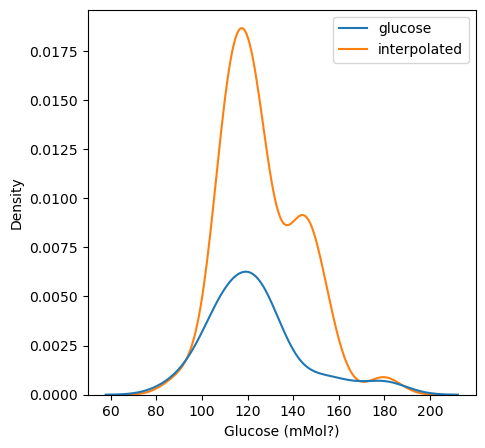

```python
import matplotlib.pyplot as plt
import seaborn as sns
plt.figure(figsize=(5,5), dpi=100)
sns.kdeplot(data=df[['glucose', 'interpolated']])
plt.xlabel('Glucose (mMol?)')
;
```

## Part 5: Plot the data

Create a plot with the original data and the interpolated data. Consider what the best representation is for visualisation of actual values and modelled/imputed values. Provide argumentation for the plot of choice.

Mind you, there are several types of plots. The most used are:

- Compare values-> Bar, boxplot, violin plot, scatter, line.
- Show composition-> Stacked bar, pie, mosaic, area, burtin.
- Show distribution-> Histogram, density, qqplot, bubble.
- Analyzing trend-> Line, bar, dual axis
- Relations-> Scatter, heatmap

### Code your solution

```python
from bokeh.io import output_notebook
from bokeh.plotting import figure, show
from bokeh.layouts import gridplot
from bokeh.io import output_notebook
from bokeh.plotting import ColumnDataSource
output_notebook()

p = figure(title='Interopolated and measured glucose values over time',
           x_axis_type='datetime', x_axis_label='Time in hours',
           y_axis_label = 'Glucose (mMol)')

p.circle(x=df['time'], y=df['interpolated'],
         legend_label='Interpolated glucose values',
         size=10, alpha=0.2, color='red')

p.circle(x=df['time'], y=df['glucose'],
         legend_label='Measured glucose values',
         color='orange', size=10)

p.legend.title = 'Legend'
p.legend.location = 'top_left'

show(p)
```

[interactive chart not shown]

## Part 6: Challenge

It might even be interesting to introduce a widget in which you can select different methods to interpolate.

1. Can you improve the interpolation by choosing an other method?
2. Can you add an rolling mean line?
3. Can you improve the plot by making it interactive?

### Code your solution

```python
import panel as pn
pn.extension()

dft = df.set_index('time')
interpolation = ['linear', 'time', 'pad', 'nearest','zero']
columns = ['glucose', 'interpolated']

# method to create the interpolated and rolling mean values
def interpolate_values(method='time'):
    dft['interpolated'] = dft['glucose'].interpolate(method)
    dft['rolling_interpolated_5'] = dft['interpolated'].rolling(5).mean()

# checkbox = CheckboxGroup(label=columns)
# I wanted to make tickboxes for the different elements in the figure
# Sadly I couldn't manage that yet.

def render_plot(x='time', y='glucose', method='time'):
    interpolate_values(method)

    p = figure(title='Glucose over time',
               x_axis_type='datetime', x_axis_label='Time in hours',
               y_axis_label = 'Glucose (mMol)')

    if y=='glucose':
        p.circle(x=dft.index, y=dft[y],
                 legend_label='Measured glucose values',
                 color='blue', size=10, alpha=0.5)

    if y=='interpolated':

        p.circle(x=dft.index, y=dft[y],
                 legend_label=f'Interpolated glucose values',
                 color='orange', size=10, alpha=0.5)

        p.circle(x=dft.index, y=dft['glucose'],
                legend_label='Measured values', size=10, alpha=0.5, color='blue')

        p.line(x=dft.index, y=dft['rolling_interpolated_5'],
               legend_label='Rolling average', color='pink', line_width=3)

    p.legend.title = 'Legend'
    p.legend.location = 'top_left'

    return p

inter_plot = pn.interact(render_plot, y=columns, method=interpolation)
inter_plot
```

[interactive chart not shown]